# Project - Data Mining

## Problem 1: Clustering

#### Problem Statement:

A leading bank wants to develop a customer segmentation to give promotional offers to its customers. They collected a sample that summarizes the activities of users during the past few months. You are given the task to identify the segments based on credit card usage.

#### Data Dictionary for Market Segmentation:

1. spending: Amount spent by the customer per month (in 1000s)
2. advance_payments: Amount paid by the customer in advance by cash (in 100s)
3. probability_of_full_payment: Probability of payment done in full by the customer to the bank
4. current_balance: Balance amount left in the account to make purchases (in 1000s)
5. credit_limit: Limit of the amount in credit card (10000s)
6. min_payment_amt : minimum paid by the customer while making payments for purchases made monthly (in 100s)
7. max_spent_in_single_shopping: Maximum amount spent in one purchase (in 1000s)

### 1.1 Read the data, do the necessary initial steps, and exploratory data analysis (Univariate, Bi-variate, and multivariate analysis).

#### Importing all required libraries:

```python
import numpy as np
import pandas as pd
import matplotlib.pyplot as plt
%matplotlib inline
import seaborn as sns
```

```python
#Reading the dataset

bank_df = pd.read_csv('D:\\SHUBHANK !\\GL\\5. TOPIC 4 - Data Mining\\Final Project\\bank_marketing_part1_Data.csv')
```

```python
#Head of the dataset

bank_df.head()
```

|  | spending | advance_payments | probability_of_full_payment | current_balance | credit_limit | min_payment_amt | max_spent_in_single_shopping |
| --- | --- | --- | --- | --- | --- | --- | --- |
| 0 | 19.94 | 16.92 | 0.8752 | 6.675 | 3.763 | 3.252 | 6.550 |
| 1 | 15.99 | 14.89 | 0.9064 | 5.363 | 3.582 | 3.336 | 5.144 |
| 2 | 18.95 | 16.42 | 0.8829 | 6.248 | 3.755 | 3.368 | 6.148 |
| 3 | 10.83 | 12.96 | 0.8099 | 5.278 | 2.641 | 5.182 | 5.185 |
| 4 | 17.99 | 15.86 | 0.8992 | 5.890 | 3.694 | 2.068 | 5.837 |

```python
#Shape of the dataset

bank_df.shape

print('Number of rows    :', bank_df.shape[0])
print('Number of columns :', bank_df.shape[1])
```

```
Number of rows    : 210
Number of columns : 7
```

```python
#Describing the dataset

bank_df.describe().T
```

|  | count | mean | std | min | 25% | 50% | 75% | max |
| --- | --- | --- | --- | --- | --- | --- | --- | --- |
| spending | 210.0 | 14.847524 | 2.909699 | 10.5900 | 12.27000 | 14.35500 | 17.305000 | 21.1800 |
| advance_payments | 210.0 | 14.559286 | 1.305959 | 12.4100 | 13.45000 | 14.32000 | 15.715000 | 17.2500 |
| probability_of_full_payment | 210.0 | 0.870999 | 0.023629 | 0.8081 | 0.85690 | 0.87345 | 0.887775 | 0.9183 |
| current_balance | 210.0 | 5.628533 | 0.443063 | 4.8990 | 5.26225 | 5.52350 | 5.979750 | 6.6750 |
| credit_limit | 210.0 | 3.258605 | 0.377714 | 2.6300 | 2.94400 | 3.23700 | 3.561750 | 4.0330 |
| min_payment_amt | 210.0 | 3.700201 | 1.503557 | 0.7651 | 2.56150 | 3.59900 | 4.768750 | 8.4560 |
| max_spent_in_single_shopping | 210.0 | 5.408071 | 0.491480 | 4.5190 | 5.04500 | 5.22300 | 5.877000 | 6.5500 |

```python
#Checking the null values

bank_df.isnull().sum()
```

```
spending                        0
advance_payments                0
probability_of_full_payment     0
current_balance                 0
credit_limit                    0
min_payment_amt                 0
max_spent_in_single_shopping    0
dtype: int64
```

There are no null values present in the dataset

```python
#Checking duplicates:

dups = bank_df.duplicated()

print('Number of duplicate rows = %d' % (dups.sum()))
```

```
Number of duplicate rows = 0
```

```python
#Getting the info

bank_df.info()
```

```
<class 'pandas.core.frame.DataFrame'>
RangeIndex: 210 entries, 0 to 209
Data columns (total 7 columns):
 #   Column                        Non-Null Count  Dtype
---  ------                        --------------  -----
 0   spending                      210 non-null    float64
 1   advance_payments              210 non-null    float64
 2   probability_of_full_payment   210 non-null    float64
 3   current_balance               210 non-null    float64
 4   credit_limit                  210 non-null    float64
 5   min_payment_amt               210 non-null    float64
 6   max_spent_in_single_shopping  210 non-null    float64
dtypes: float64(7)
memory usage: 11.6 KB
```

There are no null values in the dataset and all the variables have the same data types(float64).

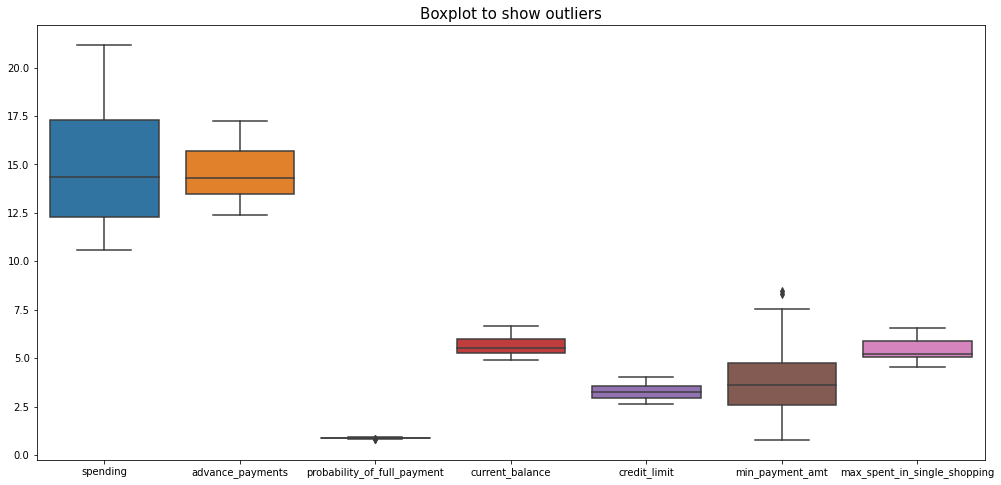

```python
#Boxplot

plt.figure(figsize=(17,8))

plt.title("Boxplot to show outliers", fontsize= 15)

sns.boxplot(data=bank_df)
```

Since, we have performed boxplot on non-scaled data, thats why there is no proper distribution of the variables.

```python
#Correlation between the variables

corr = bank_df.corr(method='pearson')

corr
```

|  | spending | advance_payments | probability_of_full_payment | current_balance | credit_limit | min_payment_amt | max_spent_in_single_shopping |
| --- | --- | --- | --- | --- | --- | --- | --- |
| spending | 1.000000 | 0.994341 | 0.608288 | 0.949985 | 0.970771 | -0.229572 | 0.863693 |
| advance_payments | 0.994341 | 1.000000 | 0.529244 | 0.972422 | 0.944829 | -0.217340 | 0.890784 |
| probability_of_full_payment | 0.608288 | 0.529244 | 1.000000 | 0.367915 | 0.761635 | -0.331471 | 0.226825 |
| current_balance | 0.949985 | 0.972422 | 0.367915 | 1.000000 | 0.860415 | -0.171562 | 0.932806 |
| credit_limit | 0.970771 | 0.944829 | 0.761635 | 0.860415 | 1.000000 | -0.258037 | 0.749131 |
| min_payment_amt | -0.229572 | -0.217340 | -0.331471 | -0.171562 | -0.258037 | 1.000000 | -0.011079 |
| max_spent_in_single_shopping | 0.863693 | 0.890784 | 0.226825 | 0.932806 | 0.749131 | -0.011079 | 1.000000 |

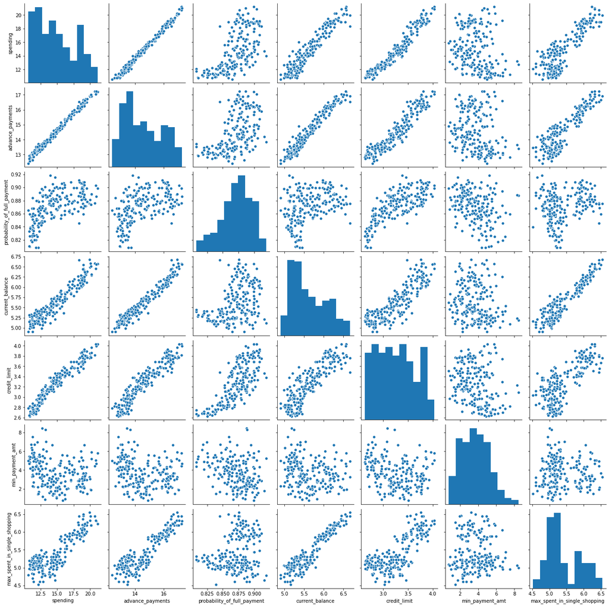

```python
#Using Pairplot, to see how the variables correlate with each other:

sns.pairplot(data= bank_df)
```

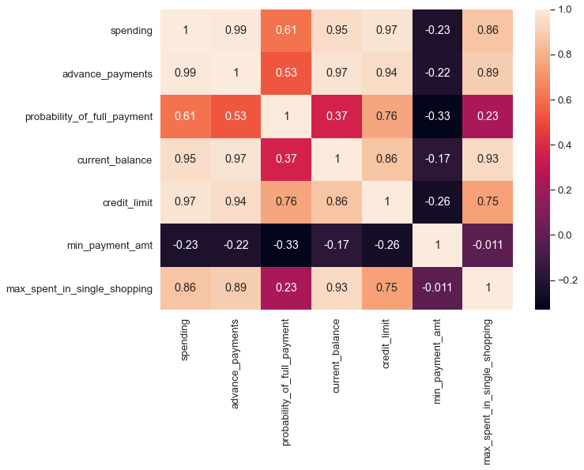

```python
#Heatmap for correlation:

plt.figure(figsize=(10,7))

sns.set(font_scale=1.2)

sns.heatmap((bank_df).corr(), annot=True)
```

## 1.2 Do you think scaling is necessary for clustering in this case? Justify

To bring all features in the same standing, we need to do scaling in this case, so that one significant number doesn’t impact the further calculations just because of their large magnitude.

We have variables in our dataset which are measured in different scales, some are in 100's , some in 1000's and some in 10000's, so it is useful to scale the data.

We are using 'zscore' from 'scipy.stats' to scale our dataset.

z scores indicate how many standard deviations an observation is above or below the mean. These scores are a useful way of putting data from different sources onto the same scale.

```python
#Scaling the 'bank_df' dataset using zscore

from scipy.stats import zscore

scaled_df = bank_df.apply(zscore)
```

```python
#Checking the head of the scaled data

scaled_df.head()
```

|  | spending | advance_payments | probability_of_full_payment | current_balance | credit_limit | min_payment_amt | max_spent_in_single_shopping |
| --- | --- | --- | --- | --- | --- | --- | --- |
| 0 | 1.754355 | 1.811968 | 0.178230 | 2.367533 | 1.338579 | -0.298806 | 2.328998 |
| 1 | 0.393582 | 0.253840 | 1.501773 | -0.600744 | 0.858236 | -0.242805 | -0.538582 |
| 2 | 1.413300 | 1.428192 | 0.504874 | 1.401485 | 1.317348 | -0.221471 | 1.509107 |
| 3 | -1.384034 | -1.227533 | -2.591878 | -0.793049 | -1.639017 | 0.987884 | -0.454961 |
| 4 | 1.082581 | 0.998364 | 1.196340 | 0.591544 | 1.155464 | -1.088154 | 0.874813 |

## 1.3 Apply hierarchical clustering to scaled data. Identify the number of optimum clusters using Dendrogram and briefly describe them.

Applying Hierarchical clustering to scaled data 'scaled_df'

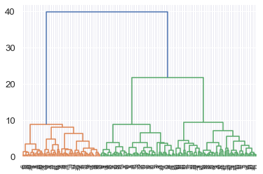

```python
#First Importing 'Dendrogram' and 'Linkage' from scipy.cluster.hierarchy

from scipy.cluster.hierarchy import dendrogram, linkage

#Using 'ward' method

wardlink = linkage(scaled_df, method = 'ward')

#Creating Dendrogram

dend = dendrogram(wardlink)
```

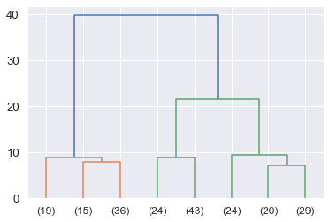

```python
dend = dendrogram(wardlink, truncate_mode='lastp', p = 8)
```

Here, truncate_mode='lastp', shows only the last p merged clusters and p=8, shows only the last 8 merged clusters.

```python
from scipy.cluster.hierarchy import fcluster
```

```python
#We are using 'maxclust' as criterion  for making clusters

clusters = fcluster(wardlink, 3, criterion='maxclust')

clusters
```

```
array([1, 3, 1, 2, 1, 2, 2, 3, 1, 2, 1, 3, 2, 1, 3, 2, 3, 2, 3, 2, 2, 2,
       1, 2, 3, 1, 3, 2, 2, 2, 3, 2, 2, 3, 2, 2, 2, 2, 2, 1, 1, 3, 1, 1,
       2, 2, 3, 1, 1, 1, 2, 1, 1, 1, 1, 1, 2, 2, 2, 1, 3, 2, 2, 3, 3, 1,
       1, 3, 1, 2, 3, 2, 1, 1, 2, 1, 3, 2, 1, 3, 3, 3, 3, 1, 2, 3, 3, 1,
       1, 2, 3, 1, 3, 2, 2, 1, 1, 1, 2, 1, 2, 1, 3, 1, 3, 1, 1, 2, 2, 1,
       3, 3, 1, 2, 2, 1, 3, 3, 2, 1, 3, 2, 2, 2, 3, 3, 1, 2, 3, 3, 2, 3,
       3, 1, 2, 1, 1, 2, 1, 3, 3, 3, 2, 2, 3, 2, 1, 2, 3, 2, 3, 2, 3, 3,
       3, 3, 3, 2, 3, 1, 1, 2, 1, 1, 1, 2, 1, 3, 3, 3, 3, 2, 3, 1, 1, 1,
       3, 3, 1, 2, 3, 3, 3, 3, 1, 1, 3, 3, 3, 2, 3, 3, 2, 1, 3, 1, 1, 2,
       1, 2, 3, 1, 3, 2, 1, 3, 1, 3, 1, 3], dtype=int32)
```

```python
#Adding the clusters columns in the dataset

bank_df['clusters'] = clusters
```

```python
bank_df
```

|  | spending | advance_payments | probability_of_full_payment | current_balance | credit_limit | min_payment_amt | max_spent_in_single_shopping | clusters |
| --- | --- | --- | --- | --- | --- | --- | --- | --- |
| 0 | 19.94 | 16.92 | 0.8752 | 6.675 | 3.763 | 3.252 | 6.550 | 1 |
| 1 | 15.99 | 14.89 | 0.9064 | 5.363 | 3.582 | 3.336 | 5.144 | 3 |
| 2 | 18.95 | 16.42 | 0.8829 | 6.248 | 3.755 | 3.368 | 6.148 | 1 |
| 3 | 10.83 | 12.96 | 0.8099 | 5.278 | 2.641 | 5.182 | 5.185 | 2 |
| 4 | 17.99 | 15.86 | 0.8992 | 5.890 | 3.694 | 2.068 | 5.837 | 1 |
| ... | ... | ... | ... | ... | ... | ... | ... | ... |
| 205 | 13.89 | 14.02 | 0.8880 | 5.439 | 3.199 | 3.986 | 4.738 | 3 |
| 206 | 16.77 | 15.62 | 0.8638 | 5.927 | 3.438 | 4.920 | 5.795 | 1 |
| 207 | 14.03 | 14.16 | 0.8796 | 5.438 | 3.201 | 1.717 | 5.001 | 3 |
| 208 | 16.12 | 15.00 | 0.9000 | 5.709 | 3.485 | 2.270 | 5.443 | 1 |
| 209 | 15.57 | 15.15 | 0.8527 | 5.920 | 3.231 | 2.640 | 5.879 | 3 |

210 rows × 8 columns

```python
x = bank_df.clusters

def customer_segmentation(column,nbins):
    print("Description of :" + column)
    print("-------------------------------------------")
    print(bank_df[column].describe(),end=' ')


    plt.figure()
    print("\n\nCustomer segmentation with respect to :" + column)
    print("-------------------------------------------")
    plt.scatter(x,bank_df[column], s=20, c='orange');
    plt.show()
```

```
Description of :spending
-------------------------------------------
count    210.000000
mean      14.847524
std        2.909699
min       10.590000
25%       12.270000
50%       14.355000
75%       17.305000
max       21.180000
Name: spending, dtype: float64

Customer segmentation with respect to :spending
-------------------------------------------
```

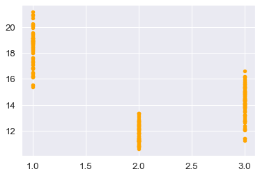

```
________________________________________________________________________


Description of :credit_limit
-------------------------------------------
count    210.000000
mean       3.258605
std        0.377714
min        2.630000
25%        2.944000
50%        3.237000
75%        3.561750
max        4.033000
Name: credit_limit, dtype: float64

Customer segmentation with respect to :credit_limit
-------------------------------------------
```

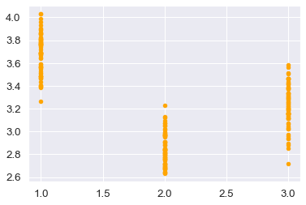

```
________________________________________________________________________


Description of :max_spent_in_single_shopping
-------------------------------------------
count    210.000000
mean       5.408071
std        0.491480
min        4.519000
25%        5.045000
50%        5.223000
75%        5.877000
max        6.550000
Name: max_spent_in_single_shopping, dtype: float64

Customer segmentation with respect to :max_spent_in_single_shopping
-------------------------------------------
```

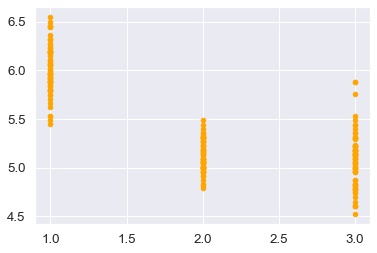

```python
customer_segmentation('spending',20)


print('\n\n________________________________________________________________________\n\n')

customer_segmentation('credit_limit',20)

print('\n\n________________________________________________________________________\n\n')

customer_segmentation('max_spent_in_single_shopping',20)
```

We can see maximum monthly expenditure is done by the customers of cluster 1. The maximum amount that spent monthly is around 21000 by the user from cluster 1. The minimum amount spent monthly is around 10000 from the user of cluster 2.

Maximum amount spent in single shopping is also done by the user of cluster 1 that is around 6500. Minimum amount spent in single shopping is done by the user of cluster 3 that is around 4500.

### 1.4 Apply K-Means clustering on scaled data and determine optimum clusters. Apply elbow curve and silhouette score. Explain the results properly. Interpret and write inferences on the finalized clusters.

```python
#First, Importing KMeans from sklearn.cluster

from sklearn.cluster import KMeans
```

```python
#Now we need to check inertia for different number of clusters and appending them into the variable 'wss',
#to get the optimul numbers of clusters using KMeans

#within sum of squares(wss)

wss =[]

#We iterate the values of k from 1 to 7 and calculate the values of distortions for each value of k
#and calculate the distortion and inertia for each value of k in the given range

for k in range(1,8):
    k_means = KMeans(n_clusters=k)
    k_means.fit(scaled_df)
    wss.append(k_means.inertia_)

#NOTE: Inertia is the sum of squared distances of samples to their closest cluster center.
```

```python
#Checking all the inertia(within sum of squares) from 1 to 7 clusters for the scaled data

#Within Sum of Squares(wss)

wss
```

```
[1469.9999999999998,
 659.171754487041,
 430.6589731513006,
 371.1846125351018,
 327.3281094192775,
 289.46717056412893,
 264.3052234087485]
```

```python
print('For k=1, the inertia is', wss[0])
print('For k=2, the inertia is', wss[1])
print('For k=3, the inertia is', wss[2])
print('For k=4, the inertia is', wss[3])
print('For k=5, the inertia is', wss[4])
print('For k=6, the inertia is', wss[5])
print('For k=7, the inertia is', wss[6])
```

```
For k=1, the inertia is 1469.9999999999998
For k=2, the inertia is 659.171754487041
For k=3, the inertia is 430.6589731513006
For k=4, the inertia is 371.1846125351018
For k=5, the inertia is 327.3281094192775
For k=6, the inertia is 289.46717056412893
For k=7, the inertia is 264.3052234087485
```

We can see, there is significant drop in the values from 'k=1' till 'k=3', and after that there is not much difference in the values as we go further from 4th to 7th.

But still we see it on the elbow method using inertia.

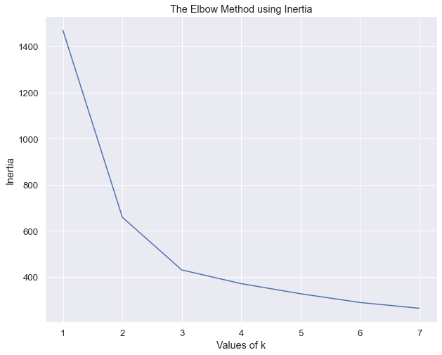

```python
#Now, we will use elbow method to select the optimum numbers of clusters

plt.figure(figsize=(10,8))

plt.plot(range(1,8), wss)

plt.xlabel('Values of k')

plt.ylabel('Inertia')

plt.title('The Elbow Method using Inertia')

plt.show()
```

To get the optimal number of clusters, we have to select the value of k at the 'elbow' that we can see in the above plot. Generally, 'elbow' is the point after which the values of the inertia start decreasing in a linear fashion.

Similarly, in our above elbow plot/method we can see that the values of inertia dropping slowly after k=3.

Therefore for our dataset, we conclude that the optimal number of clusters for the data is 3.

```python
#taking 3 as number of clusters and defining the labels to our dataset

k_means = KMeans(n_clusters = 3)
k_means.fit(scaled_df)
labels = k_means.labels_
```

```python
#alloting the column 'k_means_clusters' our dataset and labelling it

bank_df["k_means_clusters"] = labels
```

```python
bank_df.head()
```

|  | spending | advance_payments | probability_of_full_payment | current_balance | credit_limit | min_payment_amt | max_spent_in_single_shopping | clusters | k_means_clusters |
| --- | --- | --- | --- | --- | --- | --- | --- | --- | --- |
| 0 | 19.94 | 16.92 | 0.8752 | 6.675 | 3.763 | 3.252 | 6.550 | 1 | 1 |
| 1 | 15.99 | 14.89 | 0.9064 | 5.363 | 3.582 | 3.336 | 5.144 | 3 | 2 |
| 2 | 18.95 | 16.42 | 0.8829 | 6.248 | 3.755 | 3.368 | 6.148 | 1 | 1 |
| 3 | 10.83 | 12.96 | 0.8099 | 5.278 | 2.641 | 5.182 | 5.185 | 2 | 0 |
| 4 | 17.99 | 15.86 | 0.8992 | 5.890 | 3.694 | 2.068 | 5.837 | 1 | 1 |

```python
# Silhouette Score

from sklearn.metrics import silhouette_samples, silhouette_score
```

```python
silhouette_score(scaled_df,labels)
```

```
0.4007270552751299
```

As we can see that the Silhouette score for our data is positive. This means that the clusters are well separated.

```python
sil_width = silhouette_samples(scaled_df,labels)
```

```python
sil_width
```

```
array([0.57369874, 0.36638639, 0.63778363, 0.51245819, 0.36227633,
       0.21844638, 0.4728666 , 0.36181217, 0.52028453, 0.5325168 ,
       0.46759191, 0.13224116, 0.38966769, 0.5247812 , 0.11221528,
       0.22129574, 0.33795723, 0.49990157, 0.03155344, 0.2357566 ,
       0.35903729, 0.36612754, 0.43277307, 0.26136159, 0.47570507,
       0.06575223, 0.2717924 , 0.50389413, 0.55352814, 0.43430599,
       0.37707319, 0.42823997, 0.38827268, 0.39498208, 0.5345933 ,
       0.55628078, 0.50760384, 0.42334973, 0.50496507, 0.62241469,
       0.56053376, 0.48652307, 0.39923175, 0.61098901, 0.51352958,
       0.37606912, 0.30715373, 0.58258949, 0.48825724, 0.53403992,
       0.31448221, 0.49548458, 0.58601272, 0.59926567, 0.61967102,
       0.23378798, 0.44189877, 0.5384123 , 0.57674252, 0.57696905,
       0.55410258, 0.51383032, 0.55412974, 0.28131787, 0.49622138,
       0.56495699, 0.57828489, 0.5237842 , 0.63205238, 0.08288516,
       0.44353914, 0.32042362, 0.54187254, 0.58284321, 0.29226419,
       0.58740222, 0.45274186, 0.45864864, 0.36031781, 0.47235547,
       0.35417435, 0.2831762 , 0.47203593, 0.43332917, 0.54185487,
       0.11223661, 0.22242271, 0.00545677, 0.02979192, 0.16646164,
       0.20517965, 0.5183525 , 0.48637841, 0.46183334, 0.11885986,
       0.47957255, 0.52478745, 0.12866857, 0.5607693 , 0.50116166,
       0.07635312, 0.63928523, 0.35654605, 0.59044189, 0.43933781,
       0.57027048, 0.44769618, 0.27027543, 0.04661235, 0.57498168,
       0.13233096, 0.46436826, 0.53800318, 0.3679253 , 0.51909228,
       0.37156469, 0.4551955 , 0.02350739, 0.55969347, 0.57258487,
       0.09100925, 0.49344017, 0.31608966, 0.23522984, 0.45363846,
       0.47464838, 0.46014082, 0.58243476, 0.5138668 , 0.51914758,
       0.53329198, 0.49191608, 0.126471  , 0.54960064, 0.55440964,
       0.5234821 , 0.46225939, 0.47523201, 0.29475089, 0.3672136 ,
       0.21082087, 0.5124197 , 0.49210569, 0.36077109, 0.00758394,
       0.47903987, 0.50875345, 0.56149935, 0.4665377 , 0.49796266,
       0.2933896 , 0.33914323, 0.55061142, 0.11954055, 0.15438564,
       0.43772026, 0.0147342 , 0.58727725, 0.49253235, 0.50982822,
       0.55039802, 0.16465047, 0.4923075 , 0.40688005, 0.56328221,
       0.52812855, 0.08356374, 0.4883814 , 0.28327002, 0.31463815,
       0.29994534, 0.55293118, 0.5327705 , 0.48314156, 0.54160451,
       0.55177632, 0.45981976, 0.0473607 , 0.08235604, 0.44057444,
       0.48352558, 0.08180233, 0.27528811, 0.405653  , 0.24838999,
       0.34038446, 0.04968614, 0.40448831, 0.36979337, 0.44827555,
       0.00271309, 0.37107701, 0.49526093, 0.54780938, 0.48791268,
       0.26514219, 0.59782639, 0.39559692, 0.6139783 , 0.47242729,
       0.52434091, 0.09698616, 0.51856563, 0.51075769, 0.04663163,
       0.31052936, 0.26754472, 0.5067837 , 0.25736883, 0.04169976])
```

Sil_width is positive, that means the mapping is correct to its centroid.

```python
bank_df["sil_width"] = sil_width

bank_df.head(5)
```

|  | spending | advance_payments | probability_of_full_payment | current_balance | credit_limit | min_payment_amt | max_spent_in_single_shopping | clusters | k_means_clusters | sil_width |
| --- | --- | --- | --- | --- | --- | --- | --- | --- | --- | --- |
| 0 | 19.94 | 16.92 | 0.8752 | 6.675 | 3.763 | 3.252 | 6.550 | 1 | 1 | 0.573699 |
| 1 | 15.99 | 14.89 | 0.9064 | 5.363 | 3.582 | 3.336 | 5.144 | 3 | 2 | 0.366386 |
| 2 | 18.95 | 16.42 | 0.8829 | 6.248 | 3.755 | 3.368 | 6.148 | 1 | 1 | 0.637784 |
| 3 | 10.83 | 12.96 | 0.8099 | 5.278 | 2.641 | 5.182 | 5.185 | 2 | 0 | 0.512458 |
| 4 | 17.99 | 15.86 | 0.8992 | 5.890 | 3.694 | 2.068 | 5.837 | 1 | 1 | 0.362276 |

```python
#Saving and Storing this above dataset into a seperate csv file

bank_df.to_csv('bank_Clustering1.csv')
```

#### Inference:

We can see that there is not much decline in the values as we go further from 4th to 7th clusters, that's why we have decided to keep the optimum number of cluster equal to 3.

The data is well separated within these 3 clusters. This we can say by directly looking at the silhouette score.

Therefore for our dataset, we conclude that the optimal number of clusters for the data is 3.